# Data Visualization / Group Project 8(A)

# Plot 8 -> Number of Reads vs Endogenous Content

### This plot indicates if samples with higher endogenous content have more reads

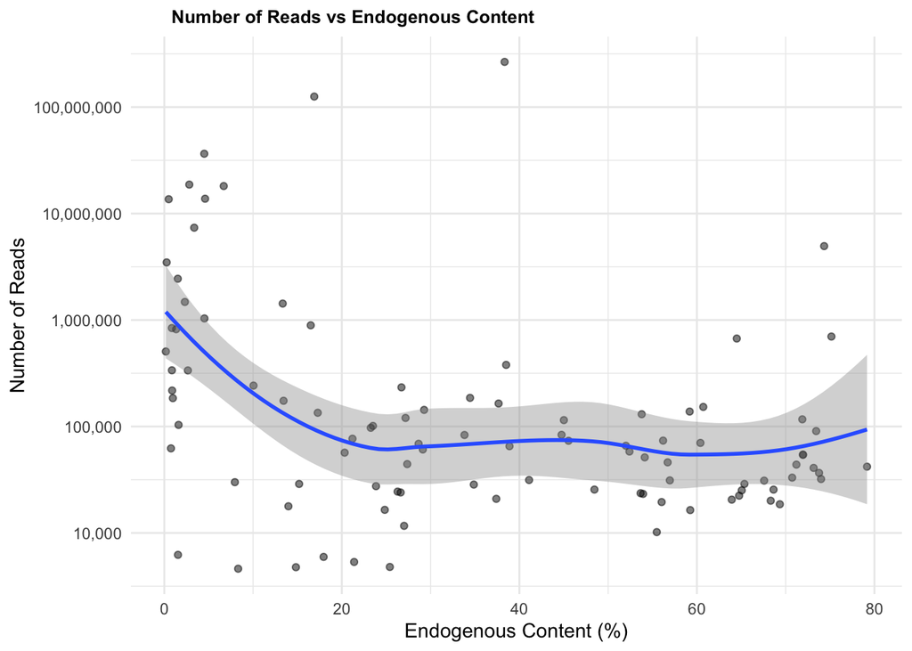

```r
library(scales)
ggplot(df, aes(x = `endogeneous_content`, y = number_of_reads)) +
    geom_point(alpha = 0.5)+ #Draws every observation as a point
    geom_smooth() +
    scale_y_log10(labels = scales::comma) +
    labs(
      title = "Number of Reads vs Endogenous Content",
      x = "Endogenous Content (%)",
      y = "Number of Reads",
    ) +
    theme_minimal() +
    theme(
      plot.title = element_text(size = 10, face = "bold", hjust = 0.1)
    )
```

## 3. Explain your data with graphics and text:

### 1. Choose the three graphics that better describe your data.

### 2. Customize and annotate them.

### 3. Accompany the figures with your hypothesis and/or interpretation.

## 1st graphic : Number of reads by country

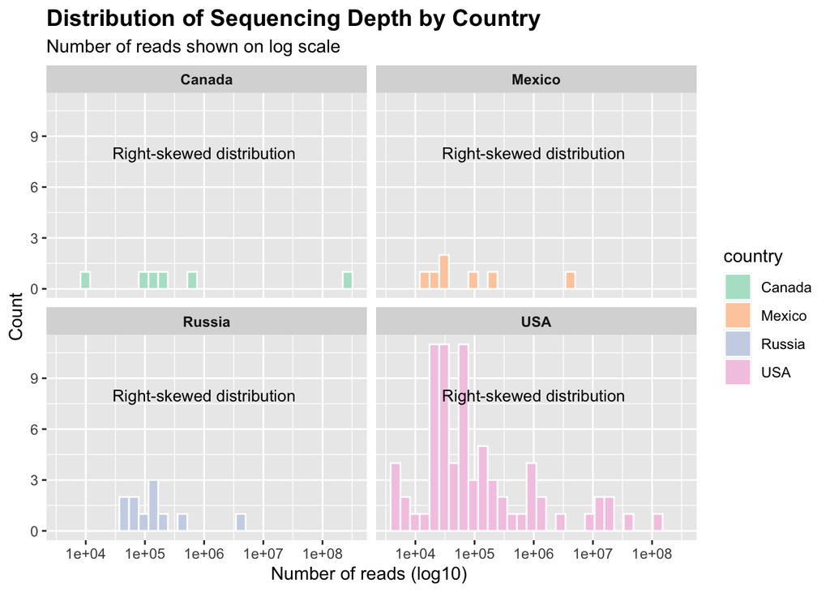

```r
ggplot(df, aes(x = number_of_reads,fill = country)) +
  geom_histogram(bins = 30,color = "white") +
  scale_x_log10() + facet_wrap(~country) +
  scale_fill_brewer(palette = "Pastel2") +
  labs(title = "Distribution of Sequencing Depth by Country",
       subtitle = "Number of reads shown on log scale",
       x ="Number of reads (log10) ", y= "Count") +
  theme(plot.title = element_text(face = "bold", size = 14),
      plot.subtitle = element_text(size = 11),
      strip.text = element_text(face = "bold")) +
      annotate("text",
           x = 1e6,
           y = 8,
           label = "Right-skewed distribution",
           size = 3.5)
```

### Hypothesis:

> We hypothesize that number of reads may vary across countries due to differences in sample preservation conditions, excavation context, and laboratory processing strategies.

### Interpretation:

> The distribution of read counts is highly right-skewed across all countries, even after log transformation. The USA shows greater variability and a wider range of sequencing depth compared to other countries, likely reflecting differences in sample size and sequencing effort. These patterns suggest that technical and sampling factors may play a substantial role in shaping sequencing output.

## 2nd graphic : Endogenous Content by Dog/Wolf Status

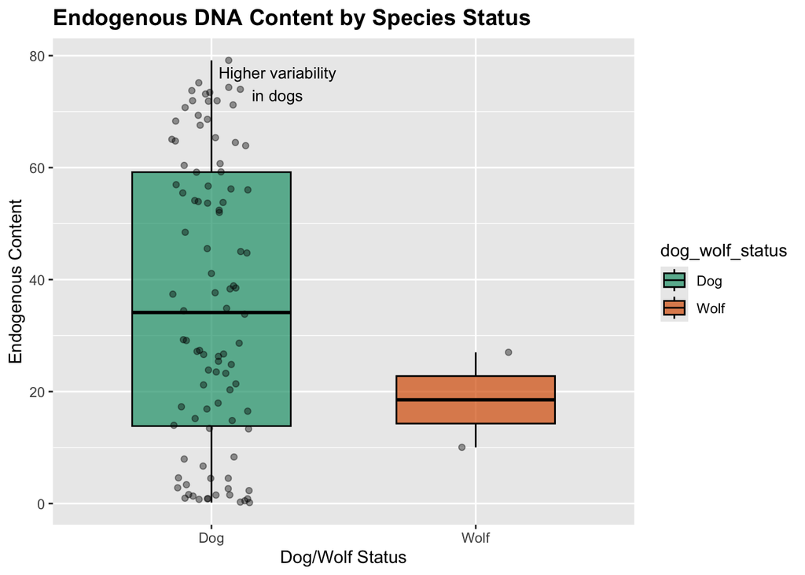

```r
ggplot(df, aes(x = dog_wolf_status, y = endogeneous_content,fill = dog_wolf_status)) +
  geom_boxplot(color = "black", alpha = 0.7, width = 0.6) +
  geom_jitter(width = 0.15, alpha = 0.4, show.legend = FALSE) +
  scale_fill_brewer(palette = "Dark2") +
  labs(title = "Endogenous DNA Content by Species Status",
       x ="Dog/Wolf Status", y = "Endogenous Content") +
  theme(
      plot.title = element_text(face = "bold", size = 14),
      plot.subtitle = element_text(size = 11),
      strip.text = element_text(face = "bold")) +
  annotate("text",
           x = 1.25,
           y = 75,
           label = "Higher variability\nin dogs",
           size = 3.5)
```

### Hypothesis:

> We hypothesize that endogenous DNA content will not differ substantially between dogs and wolves, as DNA preservation is primarily influenced by environmental and burial conditions rather than taxonomic status.

### Interpretation:

> The distribution of endogenous content shows greater variability in dogs compared to wolves. While dogs appear to exhibit a higher median endogenous content, the wide dispersion and unequal sample sizes suggest caution in interpretation. The broader range observed in dogs may reflect differences in archaeological context, preservation environments, or sampling intensity rather than intrinsic biological differences between species.

## 3rd graphic : Endogenous Content by Country

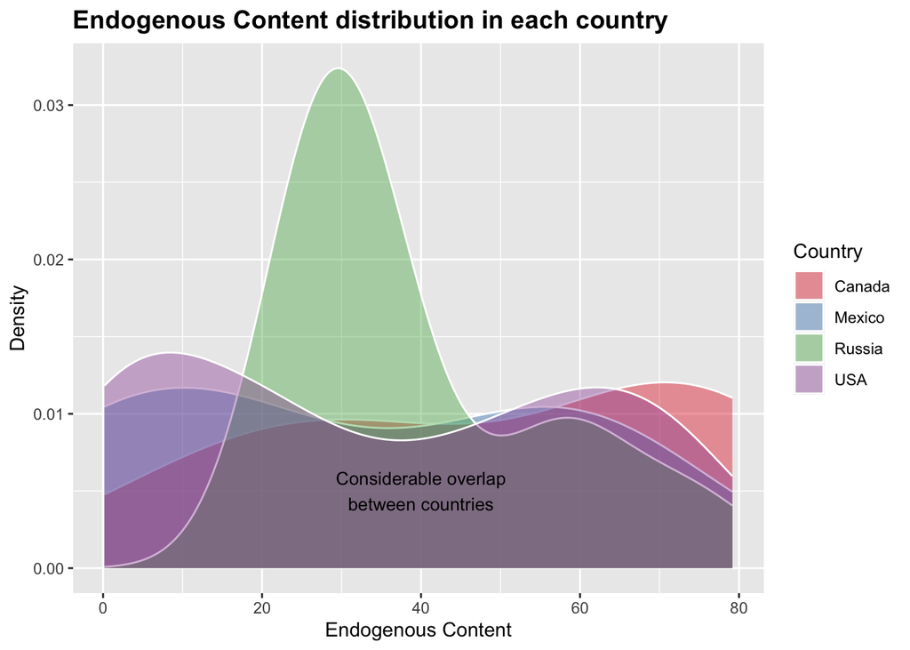

```r
ggplot(df, aes(x = endogeneous_content, fill = country)) +
  geom_density(alpha = 0.4, color = "white", na.rm = TRUE) +
  scale_fill_brewer(palette = "Set1") +
  labs(title = "Endogenous Content distribution in each country",
       x = "Endogenous Content", y = "Density", fill = "Country") +
  theme(
      plot.title = element_text(face = "bold", size = 14),
      plot.subtitle = element_text(size = 11),
      strip.text = element_text(face = "bold")) +
  annotate("text",
           x = 40,
           y = 0.005,
           label = "Considerable overlap\nbetween countries",
           size = 3.5)
```

### Hypothesis:

> We hypothesize that endogenous DNA content may vary geographically due to differences in climatic conditions, burial environments, and site-specific taxonomic processes.

### Interpretation:

> The density distributions suggest some geographic variation in endogenous content. Samples from Russia appear to cluster around intermediate values, while Canada and the USA show broader distributions including higher endogenous percentages. However, substantial overlap among countries indicates that geographic location alone does not fully explain variation in DNA preservation. Environmental heterogeneity within countries and unequal sample sizes likely contribute to the observed patterns.

# Part C

### 1. Make your figures interactive in three different ways (one for each figure):

##### - Make an interactive visualisation using some htmlwidget

##### - Add interactive controls with shiny input widgets to show some useful information (eg. focus on a subset, add a summary layer…). Use: modify what we see or filter the data.

##### - Make an interactive visualisation using shiny built-in interactive options in order to print the information of the individual observations. Use: making the plot itself interactive.

##### - Decide which figure would benefit from each type of interactivity and justify your choice